# 人工智慧金融市場研究與行銷

問卷蒐集從2018.05.17 - 2018.05.20

三個發送管道：

1. FB NTU交流版
2. 親友間Line傳送
3. PTT stock版

```
ptt 資料總筆數： 202
fb 總筆數： 56
Line 總筆數： 130
資料合計有 388 筆
```

## 單獨來看這個資料分布

ppt 問卷分佈 *請問下列何者運用到人工智慧(AI)的技術嗎？*

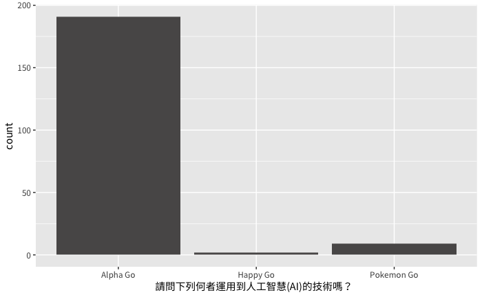

Line問卷 *請問下列何者運用到人工智慧(AI)的技術嗎？*

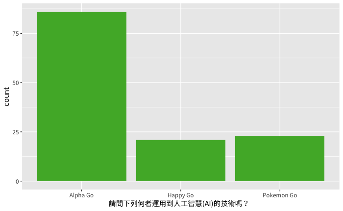

Facebook *請問下列何者運用到人工智慧(AI)的技術嗎？*

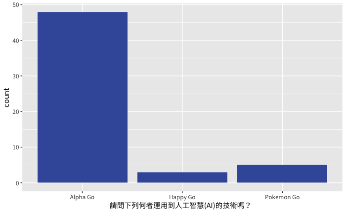

總體比較

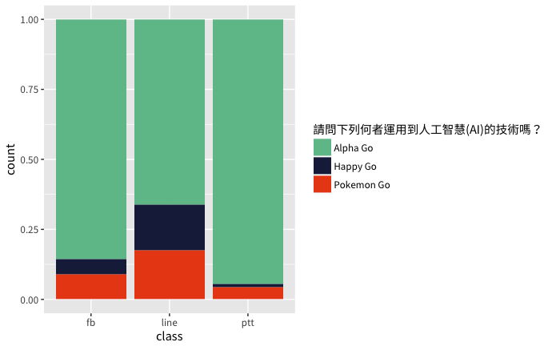

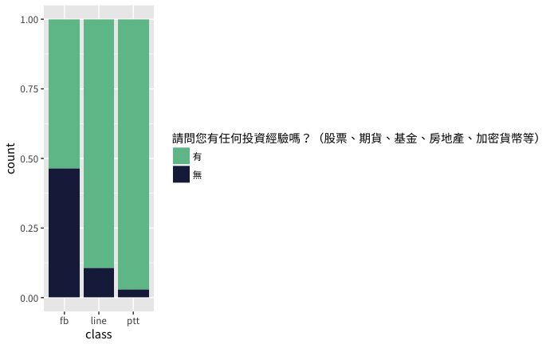

排除掉

- 請問下列何者運用到人工智慧(AI)的技術嗎？ 答錯的
- 請問您有任何投資經驗嗎？（股票、期貨、基金、房地產、加密貨幣等）? 沒有任何投資經驗的

是我們主要研究的對象，共有288筆資料

先看資料分布，有效的資料大多來自ppt

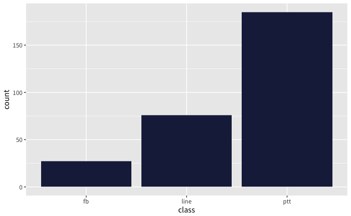

左圖為 未篩選，右圖為篩選過後的性別分布

代表性別分布其實和問卷來源叫有關係，但因為ptt資料數較多，導致問卷以**男性居多**

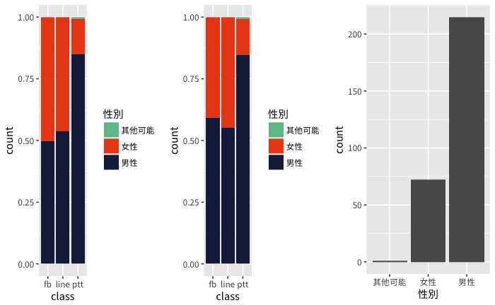

有效問卷年齡分佈在20-40歲，以21-25最多

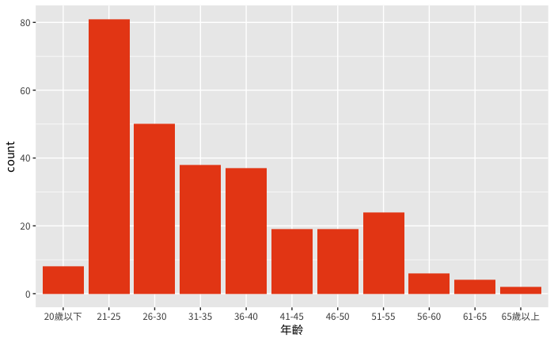

## 信度分析

透過信度分析，來了解哪一部分的題目可以採用，擁有一制性的回答

**P1** alpha

`r`r a1$total$std.alpha

```
[1] 0.65795
```

**P2** alpha 太低，刪掉此部分

`r`r a2$total$std.alpha

```
[1] 0.1423643
```

**P3** alpha

`r`r a3$total$std.alpha

```
[1] 0.800099
```

**P4** alpha

`r`r a4$total$std.alpha

```
[1] 0.8032044
```

#### 所以我們最後只利用P1,P3,P4進行分群和分析

此為分群的二維分佈圖

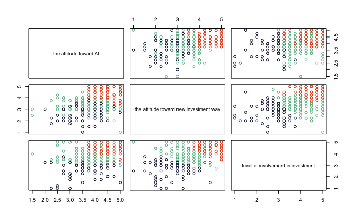

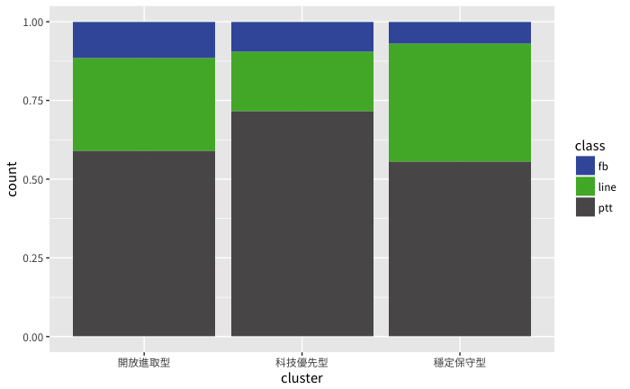

無明顯差異，再搵定保守型的女性回答者較多

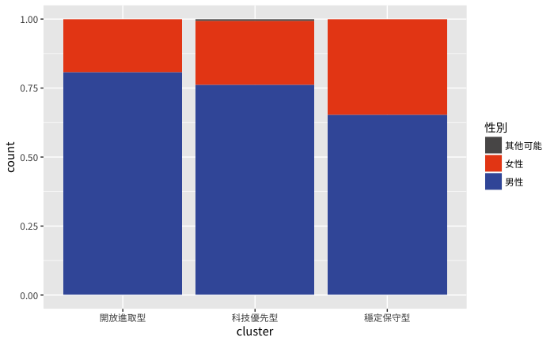

從圖中，可以發現穩定保守型的年齡分佈較年長，而開放進取型則集中於20-30歲

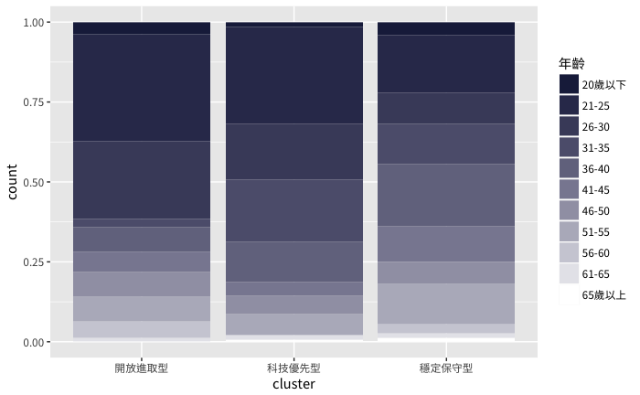

## 分群

`r`r dt.a$cluster %>% table()

```
.
開放進取型 科技優先型 穩定保守型
        78        138         72
```

## factor analysis

`r`r print(f$loadings)

```
Loadings:
                                                                                                        Factor1 Factor2 Factor3 Factor4
我相信人工智慧可以為人類帶來更美好的未來。                                                               0.207   0.132   0.787
透過人工智慧能讓世界更有效率。                                                                           0.116   0.146   0.686
美好的未來需要仰賴更先進的科技技術。                                                                     0.171   0.126   0.787
相較於理財機器人，我比較願意相信投資顧問。                                                                                       0.140
在選擇投資方式時，我更適合低風險、低報酬，比較不適合高風險、高報酬。                                                            -0.788
藉由工作一點一滴的累積財富，才能令我感到踏實且安心。                                                                            -0.401
即使會冒著較高的風險，我也想嘗試用投資賺大錢。                                                           0.186   0.262           0.456
下列選項顯示了5種不同投資組合在較短投資期間（如1年）內的潛在收益和損失*。您認為哪一種投資組合最吸引您？  0.284   0.189           0.386
我希望增加不同的投資方式。                                                                               0.593   0.241   0.157
我希望改變目前的投資方式。                                                                               0.722   0.103   0.115
如果現在有一種新的投資方式，我願意嘗試看看。                                                             0.719   0.198   0.122   0.218
我認為要有更好的投資效益，需要使用更新的投資方式。                                                       0.656   0.130   0.182
我常追蹤投資標的之相關新聞。                                                                                     0.725   0.146   0.112
我願意花時間學習新的投資方式。                                                                           0.364   0.692   0.176   0.139
我願意花錢學習新的投資方式。                                                                             0.297   0.498           0.107
我會認真研究我的投資標的。                                                                               0.101   0.742   0.162

               Factor1 Factor2 Factor3 Factor4
SS loadings      2.265   2.098   1.891   1.266
Proportion Var   0.142   0.131   0.118   0.079
Cumulative Var   0.142   0.273   0.391   0.470
```

- **factor 1** 偏向 P3
- **factor 2** 偏向 P4
- **factor 3** 偏向 P1
- **factor 4** 偏向 P2 從圖中可以看到P2表現並不好

## 降維畫圖

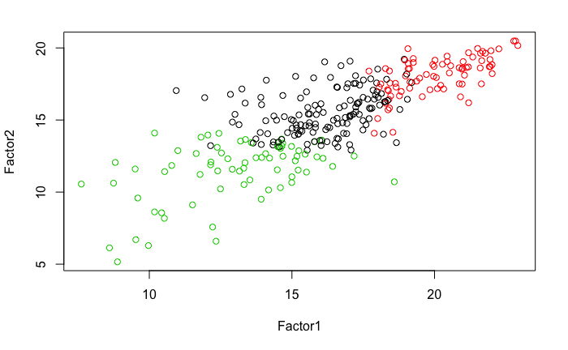